# hw5t1

hw1trial

2022-09-04

## Rishit Puri hw5

q1a

```r
require(ISLR); require(tidyverse);
```

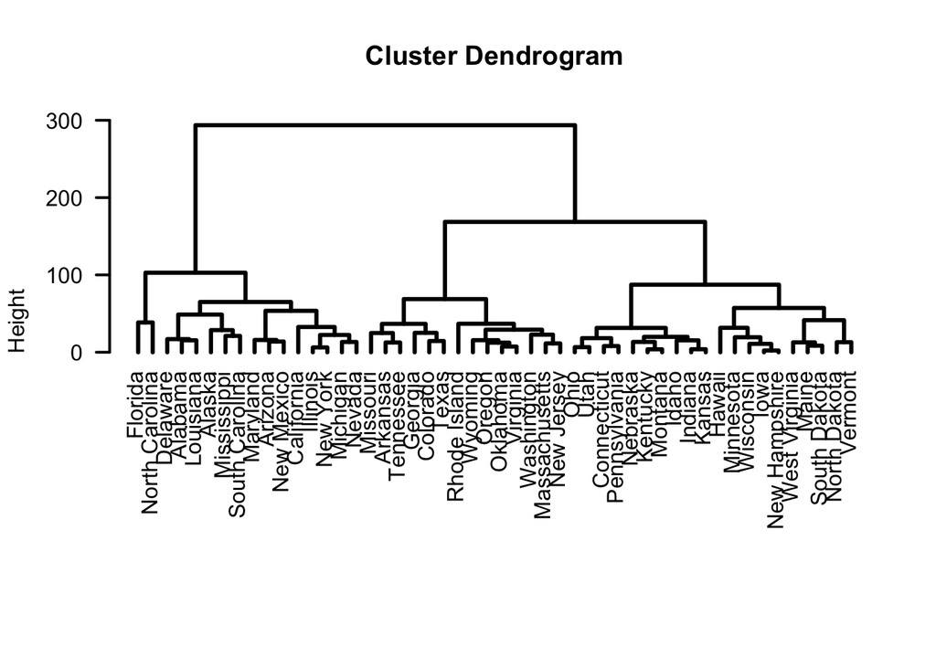

```r
data(USArrests)
usa.dist <- dist(USArrests)
usa.hclust <- hclust(usa.dist)
plot(usa.hclust, lwd = 3, lty = 1, sub = "", hang = -1, axes = FALSE, xlab = '')
axis(side = 2, at = seq(0, 300, length.out = 4), labels = FALSE, lwd = 2)
mtext(seq(0, 300, length.out = 4), side = 2, at = seq(0, 300, length.out = 4), line = 1, las = 2)
```

1b

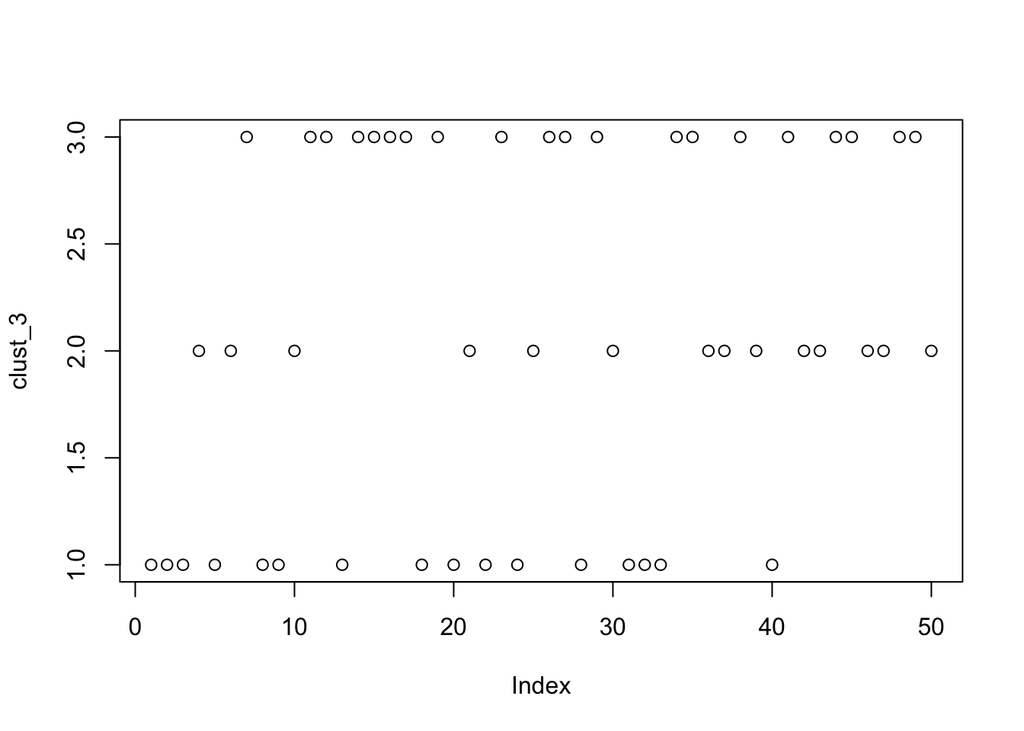

```r
clust_3 <- cutree(usa.hclust,h=120)
plot(clust_3)
```

```r
table(clust_3)
```

```
## clust_3
##  1  2  3
## 16 14 20
```

```r
clust_3
```

```
##        Alabama         Alaska        Arizona       Arkansas     California
##              1              1              1              2              1
##       Colorado    Connecticut       Delaware        Florida        Georgia
##              2              3              1              1              2
##         Hawaii          Idaho       Illinois        Indiana           Iowa
##              3              3              1              3              3
##         Kansas       Kentucky      Louisiana          Maine       Maryland
##              3              3              1              3              1
##  Massachusetts       Michigan      Minnesota    Mississippi       Missouri
##              2              1              3              1              2
##        Montana       Nebraska         Nevada  New Hampshire     New Jersey
##              3              3              1              3              2
##     New Mexico       New York North Carolina   North Dakota           Ohio
##              1              1              1              3              3
##       Oklahoma         Oregon   Pennsylvania   Rhode Island South Carolina
##              2              2              3              2              1
##   South Dakota      Tennessee          Texas           Utah        Vermont
##              3              2              2              3              3
##       Virginia     Washington  West Virginia      Wisconsin        Wyoming
##              2              2              3              3              2
```

```r
require(ape); require(RColorBrewer)
```

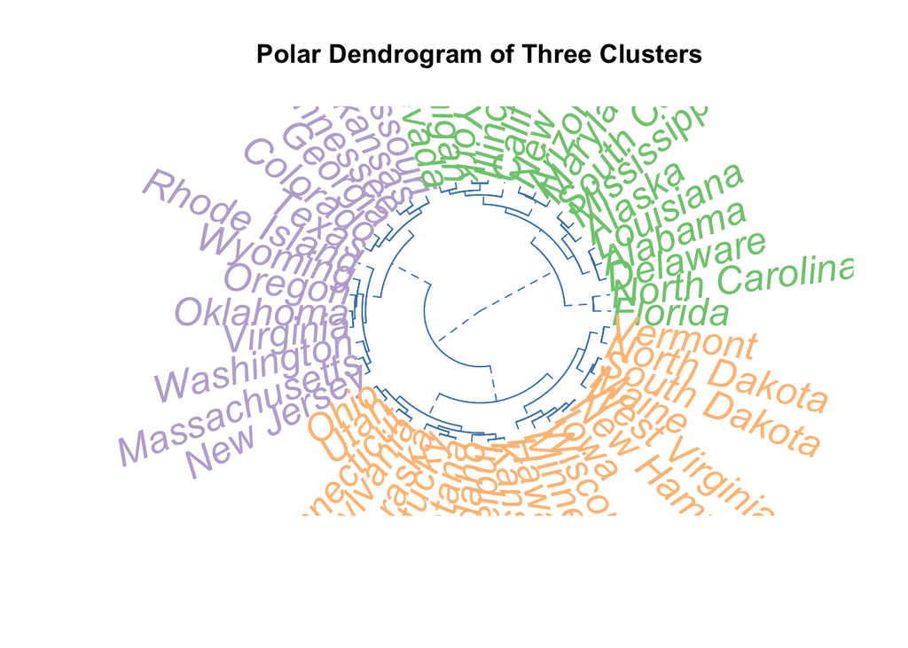

```r
plot(as.phylo(usa.hclust), type = 'fan',
     tip.color = brewer.pal(3, 'Accent')[cutree(usa.hclust, 3)],
     edge.color = 'steelblue', edge.lty = 2,
     cex = 1.8,
     main = 'Polar Dendrogram of Three Clusters')
```

1c

```r
scaling <- function(x) (x - mean(x, na.rm = TRUE)) / sd(x, na.rm = TRUE)

clust.scaled <- USArrests %>%
    map_df(scaling) %>%
    dist(method = 'euclidean') %>%
    hclust(method = 'complete')

clust.scaled$labels <- row.names(USArrests)[clust.scaled$order]
```

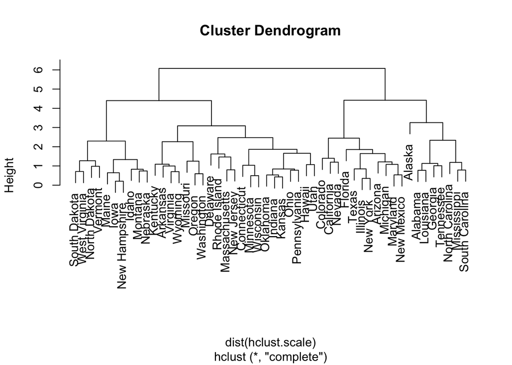

```r
hclust.scale <- scale(USArrests)
hclust.scale_ <- hclust(dist(hclust.scale),method='complete')
plot(hclust.scale_)
```

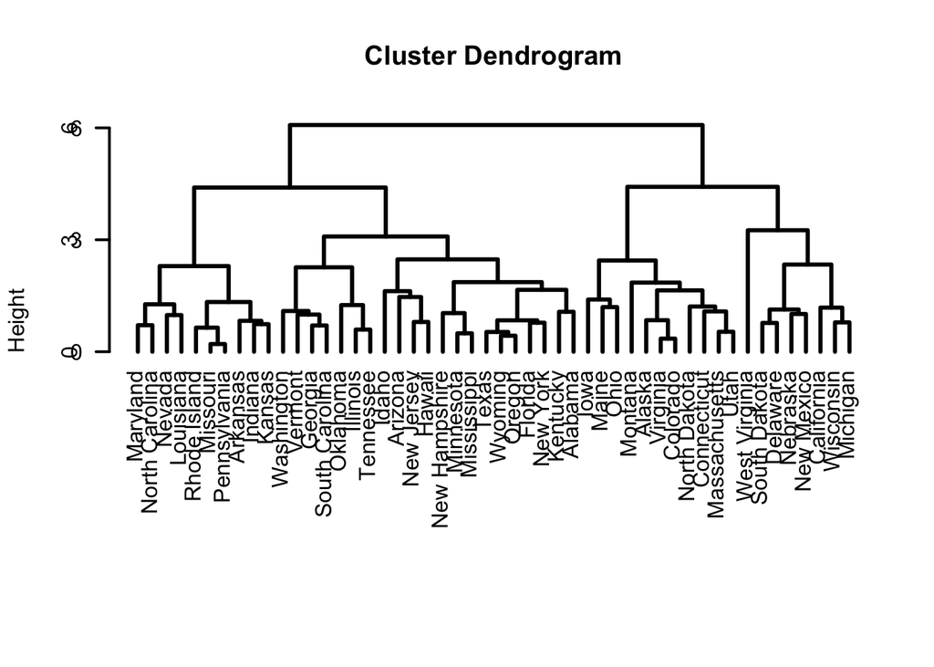

```r
plot(clust.scaled, lwd = 3, lty = 1, sub = "", hang = -1, axes = FALSE, xlab = '')
axis(side = 2, at = seq(0, 6, length.out = 3), lwd = 2)
mtext(seq(0, 6, length.out = 3), side = 2, at = seq(0, 6, length.out = 3), line = 1, las = 2)
```

1d

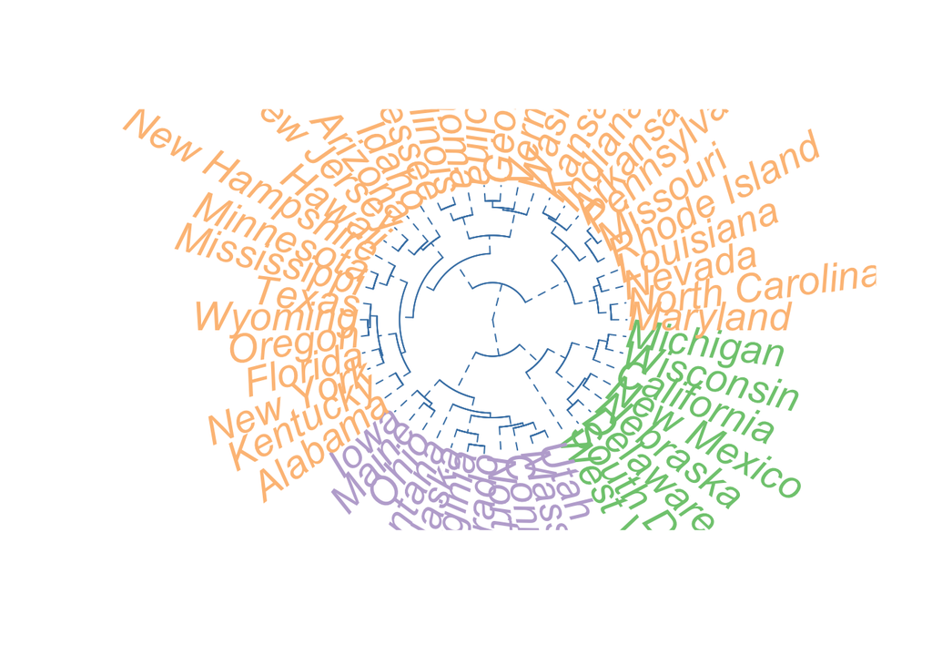

```r
plot(as.phylo(clust.scaled), type = 'fan',
     tip.color = brewer.pal(3, 'Accent')[cutree(clust.scaled, 3)],
     edge.color = 'steelblue', edge.lty = 2,
     cex = 1.8,)
```

```r
cut.hclust.scale_ <- cutree(hclust.scale_,3)
table(cut.hclust.scale_)
```

```
## cut.hclust.scale_
##  1  2  3
##  8 11 31
```

```r
cut.hclust.scale_
```

```
##        Alabama         Alaska        Arizona       Arkansas     California
##              1              1              2              3              2
##       Colorado    Connecticut       Delaware        Florida        Georgia
##              2              3              3              2              1
##         Hawaii          Idaho       Illinois        Indiana           Iowa
##              3              3              2              3              3
##         Kansas       Kentucky      Louisiana          Maine       Maryland
##              3              3              1              3              2
##  Massachusetts       Michigan      Minnesota    Mississippi       Missouri
##              3              2              3              1              3
##        Montana       Nebraska         Nevada  New Hampshire     New Jersey
##              3              3              2              3              3
##     New Mexico       New York North Carolina   North Dakota           Ohio
##              2              2              1              3              3
##       Oklahoma         Oregon   Pennsylvania   Rhode Island South Carolina
##              3              3              3              3              1
##   South Dakota      Tennessee          Texas           Utah        Vermont
##              3              1              2              3              3
##       Virginia     Washington  West Virginia      Wisconsin        Wyoming
##              3              3              3              3              3
```

We should scale the variables before euclidian distance as if the units of two variables are different then it would generate inaccurate results. Like salary and age or distance in cm and km.

2.1 temp and ozone has highest corelation

```r
load("/Users/rishit/Desktop/environmental.RData")
s_environmental <- scale(environmental)
corr.matrix <- cor(s_environmental)
corr.matrix
```

```
##                  ozone  radiation temperature       wind
## ozone        1.0000000  0.3483417   0.6985414 -0.6129508
## radiation    0.3483417  1.0000000   0.2940876 -0.1273656
## temperature  0.6985414  0.2940876   1.0000000 -0.4971459
## wind        -0.6129508 -0.1273656  -0.4971459  1.0000000
```

2.2

```r
pr.out_ <- prcomp(environmental,scale.=TRUE)
pr.out_s <- prcomp(s_environmental,scale.=TRUE)
pr.out_$center
```

```
##       ozone   radiation temperature        wind
##   42.099099  184.801802   77.792793    9.938739
```

```r
pr.out_$scale
```

```
##       ozone   radiation temperature        wind
##   33.275969   91.152302    9.529969    3.559218
```

```r
pr.out_$rotation
```

```
##                    PC1         PC2        PC3        PC4
## ozone        0.5890271 -0.06304115  0.1137638  0.7975780
## radiation    0.3168987  0.89855477 -0.2773707 -0.1234503
## temperature  0.5527125 -0.06128476  0.6585842 -0.5069713
## wind        -0.4971228  0.42996431  0.6902102  0.3026705
```

```r
pr.out_$sdev
```

```
## [1] 1.5362936 0.9458106 0.6897738 0.5190919
```

```r
pr.out_s$center
```

```
##         ozone     radiation   temperature          wind
## -1.456543e-17 -1.512491e-16 -2.741801e-16  1.003952e-16
```

```r
pr.out_s$scale
```

```
##       ozone   radiation temperature        wind
##           1           1           1           1
```

```r
s_environmental%*%pr.out_$rotation
```

```
##              PC1         PC2          PC3          PC4
## 1   -0.272745843 -0.18395702 -1.257746074  0.324876063
## 2   -0.405382983 -0.84391298 -0.593862240  0.087580088
## 3   -1.248935749  0.04997700  0.260009542 -0.244868405
## 4   -1.114896677  1.59956329 -1.261113157  0.221661598
## 5   -0.496021970  1.08246157 -1.556471601 -0.045739196
## 6   -2.336421975 -0.21474620 -0.367805385  0.890638173
## 7   -3.573201376 -0.23432751  1.197944006  1.164677436
## 8   -0.691073966  0.77900103 -0.959816238 -0.274531104
## 9   -0.765532407  1.08252702 -1.384650962 -0.323347774
## 10  -0.889501609  1.11162354 -0.857827077 -0.191602461
## 11  -2.446521293 -0.61406560 -0.453224095  0.914891311
## 12  -0.996698884  1.80129212 -1.200476743 -0.009048862
## 13  -0.690382506  1.54478355 -0.814767256  0.443013905
## 14  -3.398032349  0.17142535  0.405479335  1.105059669
```

[output cut: 97 more lines]

2.3 Two largest loadings of pc1 is ozone and temp. As seen in the first question ozone and temp has high correlation. Ozone and temp has the most affect on pc1.

2.4

```r
summary(pr.out_)$importance
```

```
##                             PC1       PC2       PC3       PC4
## Standard deviation     1.536294 0.9458106 0.6897738 0.5190919
## Proportion of Variance 0.590050 0.2236400 0.1189500 0.0673600
## Cumulative Proportion  0.590050 0.8136900 0.9326400 1.0000000
```

As seen from the cumulative proportion pc1 explains only 59 percent variance. the cumulative proportion for pc1 and pc2 is 81 percent. To explain 90 percent of total variance, we have to use cumulative proportion upto pc3.

2.5

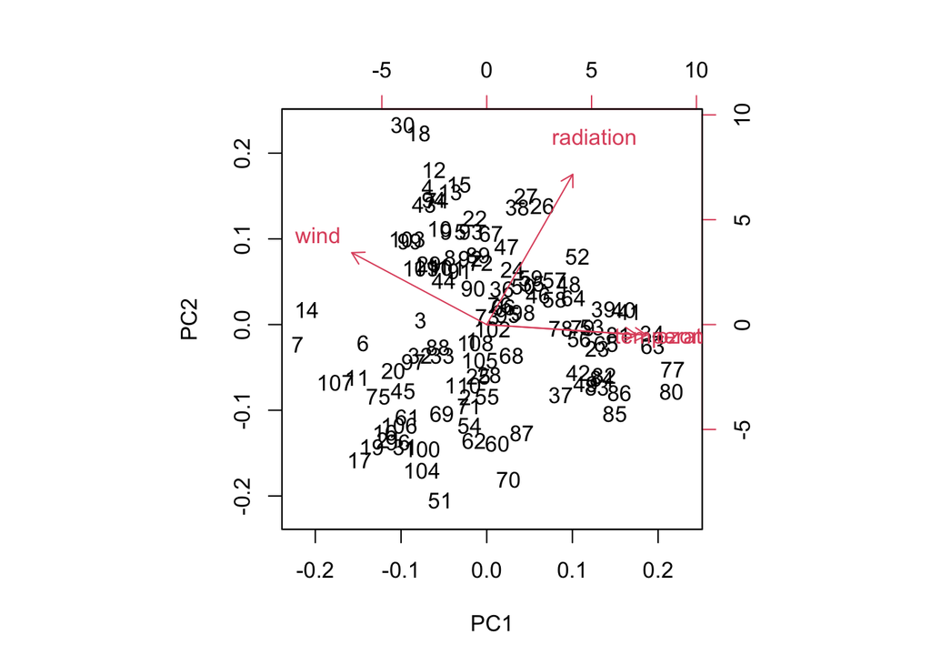

```r
biplot(pr.out_)
```

Ozone and temp has high correlation. In the biplot the xaxis is pc1 and y axis is pc2. The loadings of pc2 and pc1 are on right axis and top axis. The bottom left is bad radiation and wind and bad ozone and temp. Bottom right is bad radiation and wind and good temp and ozone. top left is bad ozone and temp and good radiation and wind. top right is good wind and radiation and good temp and ozone.